# R Homework #4

In this assignment, you are going to use your R skills to investigate interesting mathematical/statistical phenomena that can be simulated using a programming language. There will also be a web-scraping and plotting question to end on a different note!

## Question 1: Approximating Pi

The [Diophantine Approximation](https://en.wikipedia.org/wiki/Diophantine_approximation) of $\pi$. The geometric constant $\pi$ is the ratio of a circle’s circumference ($2\pi r$) to its diameter ($2r$). A classical approximation of $\pi$ is $22/7$.

**Exercise**: We are going to use our increased computing power and knowledge of the `tidyverse` to find a better rational approximation to $\pi$ using only integers at most 500. You are going to create a brute-force algorithm that checks all quotient pairs where both integers are less than 500 to see which is closest to $\pi$. Specifically, complete the following steps:

- Generate a `tibble` that contains two columns (`x` and `y`) which hold all possible combinations of integers from 1 to 500. You want to do this with a `tidyverse` function called `expand_grid()`. No for loops needed! Use the `?` operator before the function to open the help menu (run `?expand_grid`)
- Create a new column that holds the difference and subsequent comparison to the approximation that exists already in R (which is `pi`).
- Sort the column to see the smallest differences and pick out the smallest one!

## Question 2: Pi Again!

I’m still thinking about $\pi$! Let’s explore another way to approximate $\pi$, this time using an accept/reject algorithm. Consider the unit circle (centered at (0,0) and has a radius 1) that is inscribed in a square with side of length 2 (-1 to 1 in both the x and y axes). Now consider the upper-right quadrant of circle inscribed in the square. The area of that quarter-circle is $\pi/4$, and the ratio of the circle area to the square area is also $\pi/4$ (area of square is 1). Thus, if I can somehow approximate the area of the quarter-circle, I can approximate $\pi$. Now imagine I throw a bunch of darts at this inscribed circle and square combination uniformly at random (it can hit at any point in quarter-square and each point is equally likely). Because I threw the darts uniformly at random, you would expect the proportion of darts that fall inside the quarter-circle would be the same as the circle to square ratio! Thus I would get my $\pi$ approximation. To accomplish this task, complete the following:

- Theoretically throw 100000 darts uniformly at random at the region described above. This entails generating 100000 x and y coordinates independently using the `runif` function (twice) where the parameters of `runif()` are 0 and 1 (which are already defaulted). Hint: create a tibble with two columns (x and y) and use the `runif()` as directed above.
- Check to see if the randomly generated points (x,y pairs) fall into the quarter-circle or outside the circle and in the square. Hint: The equation of the unit circle is $1 = x^2 + y^2$
- Count the number of points that fall in the circle and divide by the total number of points. That will give you the area of the quarter-circle. Multiply by 4 to get the area of the whole circle, and thus an approximation of $\pi$.

## Question 3: A 538 Riddler Question

The Riddler is a weekly 538 article about math puzzles! You can find “The Riddler” weekly article here:https://fivethirtyeight.com/tag/the-riddler/. In a question from two years ago, they ask in interesting question about rolling dice. Here’s the question:

“You start with a fair 6-sided die and roll it six times, recording the results of each roll. You then write these numbers on the six faces of another, unlabeled fair die. For example, if your six rolls were 3, 5, 3, 6, 1 and 2, then your second die wouldn’t have a 4 on it; instead, it would have two 3s.

Next, you roll this second die six times. You take those six numbers and write them on the faces of yet another fair die, and you continue this process of generating a new die from the previous one.

Eventually, you’ll have a die with the same number on all six faces. What is the average number of rolls it will take to reach this state?”

**Question Starts Here:**

I want you to create a simulation to try and answer this question! David Robinson has done a screen-cast on it, but don’t copy his code! I am looking for you to use simple controls and looping structures to accomplish this task. There are only a couple of components to this problem:

- Rolling the dice: This is accomplished using the `sample()` function. The `sample()` function takes in the vector you are sampling from, the number of samples you want from the vector, and whether or not you want to sample with replacement. For example, `rsample(1:6, 3, replace = TRUE)` simulates three rolls of 1 six-sided die. Every time you roll the die, you will feed the previous roll into `sample()` again.
- Determining when to stop: No matter what type of loop you use, you need some stopping criteria. The output of sample is a vector, and so you need to know when the vector becomes all one number. I suggest a combination of the `length()` and `unique()` functions.
- Keeping count of iterations: One way or another, you have to keep track of how many iteration you went through until you have all of the same faces. This may be easily built into your simulation or you may have to add a variable that keeps count.

To complete the task, you will want to prototype your function (make sure that it works for one run of roll sequence) and then use `rerun()` to run the simulation many times (10000 or more). Then find the average of all the simulations to answer the question.

## Question 4: Web Scraping

[Wikipedia](https://en.wikipedia.org/wiki/Educational_attainment_in_the_United_States) contains information on median earnings of US households by educational level and year. Scrape the table about half-way down the page that characterizes median income by educational attainment and year. Then, recreate the below plot.

This exercise requires a combination of all the skills you’ve learned in the course so far. I’m leaving this open-ended to see what you can do!

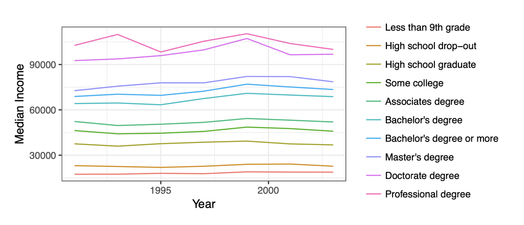